# Dimensionality Reduction Techniques

```r
date()
```

```
## [1] "Mon Dec  5 23:18:57 2022"
```

The data used in the first part is modified from the UNDP Human development Reports Human development Index dataset.The HDI is a summary measure of average achievement in key dimensions of human development: a long and healthy life, being knowledgeable and have a decent standard of living. It also includes some measures of gender equality.

More information about the Human development index can be found from https://hdr.undp.org/data-center/human-development-index#/indicies/HDI

In the dataset the name of the country is the row name

Here we use the following variables:

1. Life_Exp = Life Expectancy at Birth
2. Exp_Edu = Expected Years of Education for children entering school
3. GNI_Capita = Gross National Income (GNI) per Capita
4. Mater_Mort = Maternal Mortality Ratio
5. Ado_Birth = Adolescent Birth Rate
6. Parli_F = Percentage of female representatives in parliament
7. Edu2_ratio is caluculated ratio of female and male populations with secondary education in each country (Female/Male)
8. Labor_ratio is calculated ratio of labor force participation of females and males in each country

Bring in the libraries

```r
library(dplyr)
```

```r
library(readr)
library(tidyr)
library(corrplot)
library(GGally)
library(ggplot2)
library(FactoMineR)
library(factoextra)
```

Load the data

```r
human <- read.table("data/human.csv", sep=",", header=TRUE)
```

Check how the data looks like

```r
colnames(human)
```

```
## [1] "Edu2_ratio"  "Labor_ratio" "Life_Exp"    "Exp_Edu"     "GNI_Capita"
## [6] "Mater_Mort"  "Ado_Birth"   "Parli_F"
```

```r
dim(human)
```

```
## [1] 155   8
```

```r
str(human)
```

```
## 'data.frame':    155 obs. of  8 variables:
##  $ Edu2_ratio : num  1.007 0.997 0.983 0.989 0.969 ...
##  $ Labor_ratio: num  0.891 0.819 0.825 0.884 0.829 ...
##  $ Life_Exp   : num  81.6 82.4 83 80.2 81.6 80.9 80.9 79.1 82 81.8 ...
##  $ Exp_Edu    : num  17.5 20.2 15.8 18.7 17.9 16.5 18.6 16.5 15.9 19.2 ...
##  $ GNI_Capita : int  64992 42261 56431 44025 45435 43919 39568 52947 42155 32689 ...
##  $ Mater_Mort : int  4 6 6 5 6 7 9 28 11 8 ...
##  $ Ado_Birth  : num  7.8 12.1 1.9 5.1 6.2 3.8 8.2 31 14.5 25.3 ...
##  $ Parli_F    : num  39.6 30.5 28.5 38 36.9 36.9 19.9 19.4 28.2 31.4 ...
```

Graphical overview of the data

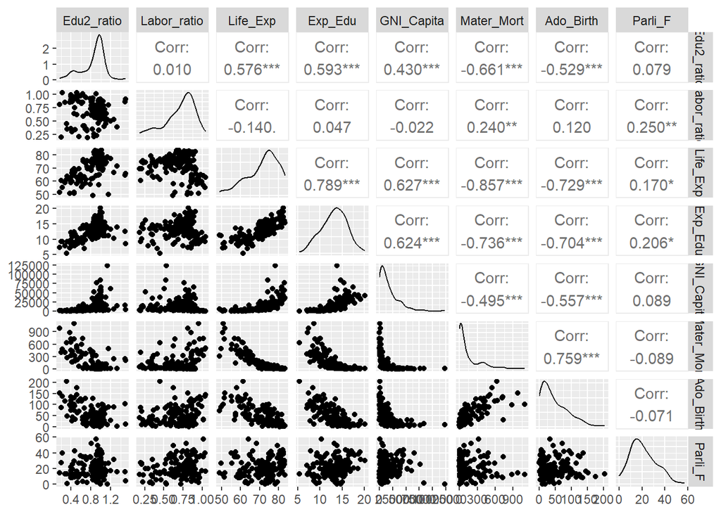

```r
ggpairs(human)
```

Summaries of the variables in the data

```r
summary(human)
```

```
##    Edu2_ratio      Labor_ratio        Life_Exp        Exp_Edu
##  Min.   :0.1717   Min.   :0.1857   Min.   :49.00   Min.   : 5.40
##  1st Qu.:0.7264   1st Qu.:0.5984   1st Qu.:66.30   1st Qu.:11.25
##  Median :0.9375   Median :0.7535   Median :74.20   Median :13.50
##  Mean   :0.8529   Mean   :0.7074   Mean   :71.65   Mean   :13.18
##  3rd Qu.:0.9968   3rd Qu.:0.8535   3rd Qu.:77.25   3rd Qu.:15.20
##  Max.   :1.4967   Max.   :1.0380   Max.   :83.50   Max.   :20.20
##    GNI_Capita       Mater_Mort       Ado_Birth         Parli_F
##  Min.   :   581   Min.   :   1.0   Min.   :  0.60   Min.   : 0.00
##  1st Qu.:  4198   1st Qu.:  11.5   1st Qu.: 12.65   1st Qu.:12.40
##  Median : 12040   Median :  49.0   Median : 33.60   Median :19.30
##  Mean   : 17628   Mean   : 149.1   Mean   : 47.16   Mean   :20.91
##  3rd Qu.: 24512   3rd Qu.: 190.0   3rd Qu.: 71.95   3rd Qu.:27.95
##  Max.   :123124   Max.   :1100.0   Max.   :204.80   Max.   :57.50
```

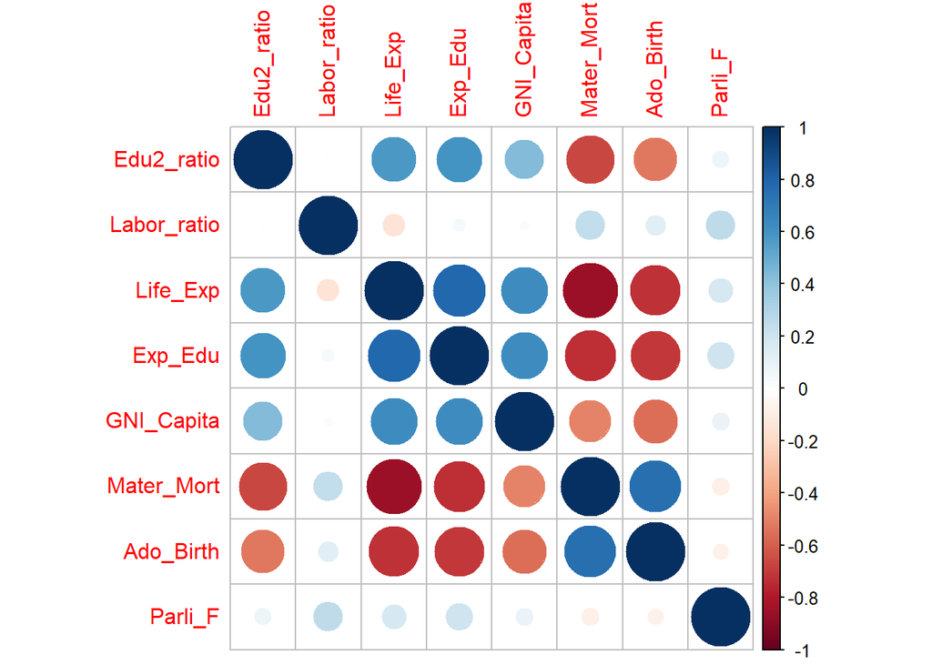

```r
cor(human) %>% corrplot()
```

The outputs confirm what we expect. The education ratio is positively correlated with Life expectancy, GNI per capita, and (this is pretty obvious) with Expected education. In countries where high numbers of women are educated, people live longer, study more and earn more. They also have lower maternal mortality rate and adolescent birth rate.

Life expectancy is positively correlated with GNI per capita. People in richer countries live longer. Life expectancy is negatively correlated with maternal mortality rate and adolscent birth rate. When maternal mortality rate and adolescent birth rate are positively correlated, it seems quite natural that when these two rates are high the life expectancy gets lower.

Expected education is positively correlated with GNI per capita. In richer countrie people study longer but also when people study longer they earn more. High expected education also lowers the maternal mortality rate and adolescent birth rates. When women stay in school longer, they have less births and they also have babies later, which both have an impact on maternal mortality rates.

In countries with high GNI per capita both maternal mortality rate and adolescent birth rate are lower. This seems also something you would expect. High income countries have more means for good public healthcare which lowers maternal birthrates and women who give birth later in their lives have usually better education so they also earn more money.

## Principal Componen Analysis

### Perform the analysis on the non-standardized data

```r
# perform principal component analysis (with the SVD method)
pca_human <- prcomp(human)

summary(pca_human)
```

```
## Importance of components:
##                              PC1      PC2   PC3   PC4   PC5   PC6    PC7    PC8
## Standard deviation     1.854e+04 185.5219 25.19 11.45 3.766 1.566 0.1912 0.1591
## Proportion of Variance 9.999e-01   0.0001  0.00  0.00 0.000 0.000 0.0000 0.0000
## Cumulative Proportion  9.999e-01   1.0000  1.00  1.00 1.000 1.000 1.0000 1.0000
```

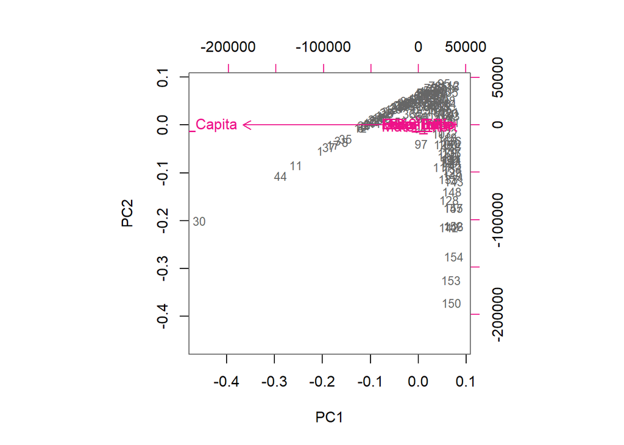

```r
# draw a biplot of the principal component representation and the original variables
biplot(pca_human, choices = 1:2, cex = c(0.8, 1), col = c("grey40", "deeppink2"))
```

### Perform the PCA on stadardized data

```r
# standardize the variables
human_std <- scale(human)

# print out summaries of the standardized variables
summary(human_std)
```

```
##    Edu2_ratio       Labor_ratio         Life_Exp          Exp_Edu
##  Min.   :-2.8189   Min.   :-2.6247   Min.   :-2.7188   Min.   :-2.7378
##  1st Qu.:-0.5233   1st Qu.:-0.5484   1st Qu.:-0.6425   1st Qu.:-0.6782
##  Median : 0.3503   Median : 0.2316   Median : 0.3056   Median : 0.1140
##  Mean   : 0.0000   Mean   : 0.0000   Mean   : 0.0000   Mean   : 0.0000
##  3rd Qu.: 0.5958   3rd Qu.: 0.7350   3rd Qu.: 0.6717   3rd Qu.: 0.7126
##  Max.   : 2.6646   Max.   : 1.6632   Max.   : 1.4218   Max.   : 2.4730
##    GNI_Capita        Mater_Mort        Ado_Birth          Parli_F
##  Min.   :-0.9193   Min.   :-0.6992   Min.   :-1.1325   Min.   :-1.8203
##  1st Qu.:-0.7243   1st Qu.:-0.6496   1st Qu.:-0.8394   1st Qu.:-0.7409
##  Median :-0.3013   Median :-0.4726   Median :-0.3298   Median :-0.1403
##  Mean   : 0.0000   Mean   : 0.0000   Mean   : 0.0000   Mean   : 0.0000
##  3rd Qu.: 0.3712   3rd Qu.: 0.1932   3rd Qu.: 0.6030   3rd Qu.: 0.6127
##  Max.   : 5.6890   Max.   : 4.4899   Max.   : 3.8344   Max.   : 3.1850
```

```r
# perform principal component analysis (with the SVD method)
pca_human_std <- prcomp(human_std)

summary(pca_human_std)
```

```
## Importance of components:
##                           PC1    PC2     PC3     PC4     PC5     PC6     PC7
## Standard deviation     2.0708 1.1397 0.87505 0.77886 0.66196 0.53631 0.45900
## Proportion of Variance 0.5361 0.1624 0.09571 0.07583 0.05477 0.03595 0.02634
## Cumulative Proportion  0.5361 0.6984 0.79413 0.86996 0.92473 0.96069 0.98702
##                            PC8
## Standard deviation     0.32224
## Proportion of Variance 0.01298
## Cumulative Proportion  1.00000
```

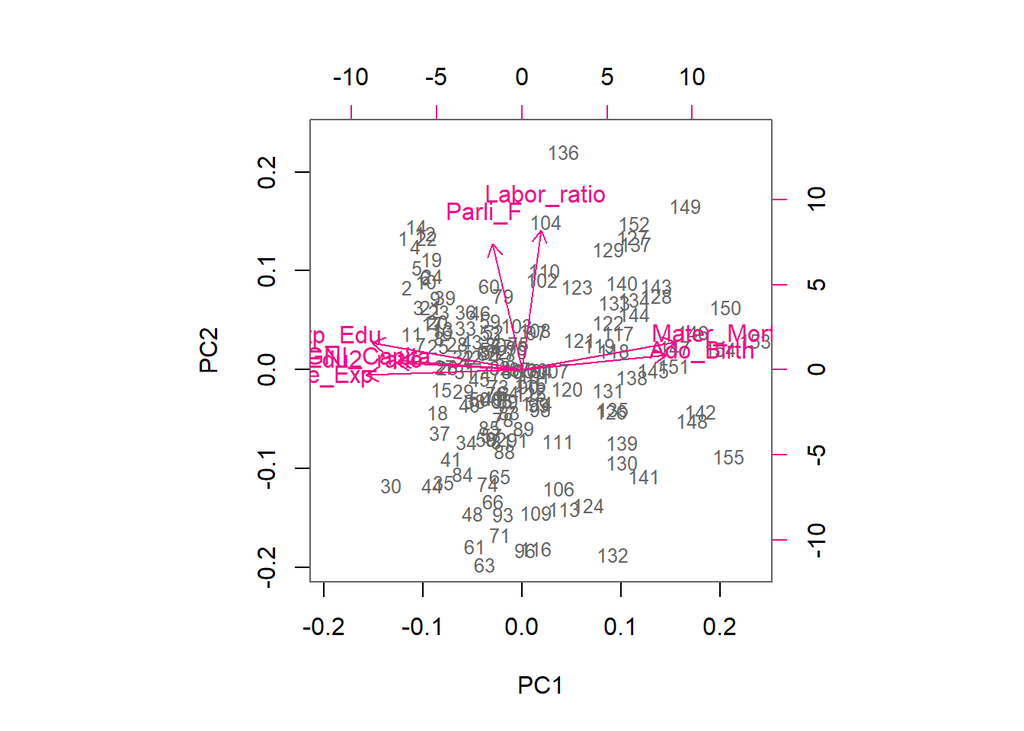

```r
# draw a biplot of the principal component representation and the original variables
biplot(pca_human_std, choices = 1:2, cex = c(0.8, 1), col = c("grey40", "deeppink2"))
```

```r
human2 <- read.table("https://raw.githubusercontent.com/KimmoVehkalahti/Helsinki-Open-Data-Science/master/datasets/human2.txt",
                    sep =",", header = T)
human2_std <- scale(human2)
summary(human2_std)
```

```
##     Edu2.FM           Labo.FM           Edu.Exp           Life.Exp
##  Min.   :-2.8189   Min.   :-2.6247   Min.   :-2.7378   Min.   :-2.7188
##  1st Qu.:-0.5233   1st Qu.:-0.5484   1st Qu.:-0.6782   1st Qu.:-0.6425
##  Median : 0.3503   Median : 0.2316   Median : 0.1140   Median : 0.3056
##  Mean   : 0.0000   Mean   : 0.0000   Mean   : 0.0000   Mean   : 0.0000
##  3rd Qu.: 0.5958   3rd Qu.: 0.7350   3rd Qu.: 0.7126   3rd Qu.: 0.6717
##  Max.   : 2.6646   Max.   : 1.6632   Max.   : 2.4730   Max.   : 1.4218
##       GNI             Mat.Mor          Ado.Birth          Parli.F
##  Min.   :-0.9193   Min.   :-0.6992   Min.   :-1.1325   Min.   :-1.8203
##  1st Qu.:-0.7243   1st Qu.:-0.6496   1st Qu.:-0.8394   1st Qu.:-0.7409
##  Median :-0.3013   Median :-0.4726   Median :-0.3298   Median :-0.1403
##  Mean   : 0.0000   Mean   : 0.0000   Mean   : 0.0000   Mean   : 0.0000
##  3rd Qu.: 0.3712   3rd Qu.: 0.1932   3rd Qu.: 0.6030   3rd Qu.: 0.6127
##  Max.   : 5.6890   Max.   : 4.4899   Max.   : 3.8344   Max.   : 3.1850
```

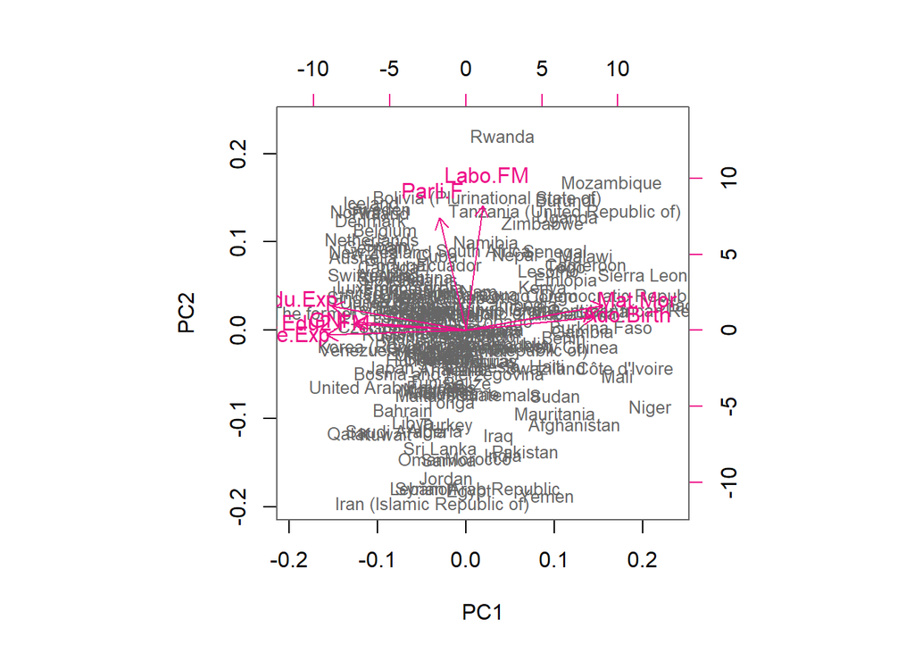

```r
pca_human2 <- prcomp(human2_std)
biplot(pca_human2, choices = 1:2, cex = c(0.8, 1), col = c("grey40", "deeppink2"))
```

I added here the table from the Exercise 5 where the country varibale is still in use. It is not much clearer (maybe the opposite) but we can see the names of some of the countries, so it might be helpful.

The difference is mainly explained with the difference of the units between the different variables. When the ratios are very small, usually around 1, GNI per capita has the highest value of over 100,000. If we use covariance matrix, like we did with the first version of the PCA, the variables with largest variances will dominate the early components. This is also why GNI_Capita variable is alone in the first biplot and all the others are all very near each other. This is also clear if we check the summary information of the first principal component analysis, according which the PC1 is explaining nearly all the variance between the components.

When we use correlation matrix instead, we standardize the unit variance. This means that all the variables in this case are equally important.We can see this from the summary table where we can see that the first component explains a little bit over 50% of the variance and we need 2 components to be able to explain just a little under 70% of the variance.

PCA is used to find the number of components that are able to provide us an adequate summary of the dataset. We can use the scree diagram to do this.

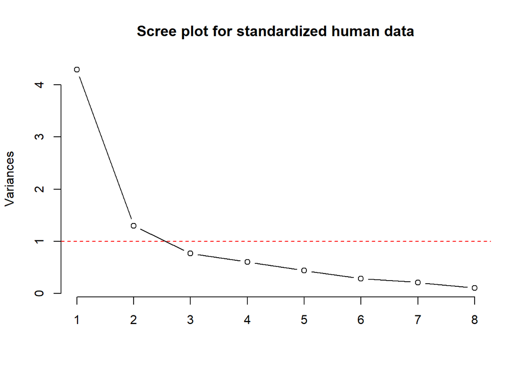

```r
screeplot(pca_human_std, type = "l", main = "Scree plot for standardized human data")
abline(1,0, col='red', lty = 2)
```

Here we can see that the scree plot suggest that two components would be enough to describe the data. This is actully the number of components we have in our biplots as well. From the biplot we can see that as the angle between the arrows indicate correlation between the variables, the mater_mort and ado_birth are quite strongly correlated with each other, the same goes with Life_Exp, Exp_Edu, GNI_Capita and Edu2_ratio. This what we also saw already from the correlation plots at the beginning.

## Tea Data

The tea data comes from the FactoMineR package and it is measured with a questionnaire on tea: 300 individuals were asked how they drink tea (18 questions) and what are their product’s perception (12 questions). In addition, some personal details were asked (4 questions). Here is the description: https://cran.r-project.org/web/packages/FactoMineR/FactoMineR.pdf

Load the tea dataset and convert its character variables to factors

```r
tea <- read.csv("https://raw.githubusercontent.com/KimmoVehkalahti/Helsinki-Open-Data-Science/master/datasets/tea.csv", stringsAsFactors = TRUE)
```

### Explore the data

Structure:

```r
str(tea)
```

```
## 'data.frame':    300 obs. of  36 variables:
##  $ breakfast       : Factor w/ 2 levels "breakfast","Not.breakfast": 1 1 2 2 1 2 1 2 1 1 ...
##  $ tea.time        : Factor w/ 2 levels "Not.tea time",..: 1 1 2 1 1 1 2 2 2 1 ...
##  $ evening         : Factor w/ 2 levels "evening","Not.evening": 2 2 1 2 1 2 2 1 2 1 ...
##  $ lunch           : Factor w/ 2 levels "lunch","Not.lunch": 2 2 2 2 2 2 2 2 2 2 ...
##  $ dinner          : Factor w/ 2 levels "dinner","Not.dinner": 2 2 1 1 2 1 2 2 2 2 ...
##  $ always          : Factor w/ 2 levels "always","Not.always": 2 2 2 2 1 2 2 2 2 2 ...
##  $ home            : Factor w/ 2 levels "home","Not.home": 1 1 1 1 1 1 1 1 1 1 ...
##  $ work            : Factor w/ 2 levels "Not.work","work": 1 1 2 1 1 1 1 1 1 1 ...
##  $ tearoom         : Factor w/ 2 levels "Not.tearoom",..: 1 1 1 1 1 1 1 1 1 2 ...
##  $ friends         : Factor w/ 2 levels "friends","Not.friends": 2 2 1 2 2 2 1 2 2 2 ...
##  $ resto           : Factor w/ 2 levels "Not.resto","resto": 1 1 2 1 1 1 1 1 1 1 ...
##  $ pub             : Factor w/ 2 levels "Not.pub","pub": 1 1 1 1 1 1 1 1 1 1 ...
##  $ Tea             : Factor w/ 3 levels "black","Earl Grey",..: 1 1 2 2 2 2 2 1 2 1 ...
##  $ How             : Factor w/ 4 levels "alone","lemon",..: 1 3 1 1 1 1 1 3 3 1 ...
```

[output cut: 22 more lines]

Dimensions:

```r
dim(tea)
```

```
## [1] 300  36
```

Browse the dataframe’s contents

```r
View(tea)
```

### Visualize the data

```r
# Let's see how different tea drinkers perceive tea: Do they think it's relaxing, sophisticated or are tea drinkers friendly (I assume that the friendliness means this, I couldn't find )

#Firs we define which columns we want to keep
keep_columns <- c("Tea", "How", "how", "sugar", "where", "age_Q", "relaxing", "sophisticated", "friendliness")

#create a new dataset with the variables we chose to keep
tea_percep <- select(tea, one_of(keep_columns))

#check how the dataframe looks like
summary(tea_percep)
```

```
##         Tea         How                      how           sugar
##  black    : 74   alone:195   tea bag           :170   No.sugar:155
##  Earl Grey:193   lemon: 33   tea bag+unpackaged: 94   sugar   :145
##  green    : 33   milk : 63   unpackaged        : 36
##                  other:  9
##
##                   where       age_Q           relaxing
##  chain store         :192   +60  :38   No.relaxing:113
##  chain store+tea shop: 78   15-24:92   relaxing   :187
##  tea shop            : 30   25-34:69
##                             35-44:40
##                             45-59:61
##            sophisticated           friendliness
##  Not.sophisticated: 85   friendliness    :242
##  sophisticated    :215   Not.friendliness: 58
##
##
##
```

```r
str(tea_percep)
```

```
## 'data.frame':    300 obs. of  9 variables:
##  $ Tea          : Factor w/ 3 levels "black","Earl Grey",..: 1 1 2 2 2 2 2 1 2 1 ...
##  $ How          : Factor w/ 4 levels "alone","lemon",..: 1 3 1 1 1 1 1 3 3 1 ...
##  $ how          : Factor w/ 3 levels "tea bag","tea bag+unpackaged",..: 1 1 1 1 1 1 1 1 2 2 ...
##  $ sugar        : Factor w/ 2 levels "No.sugar","sugar": 2 1 1 2 1 1 1 1 1 1 ...
##  $ where        : Factor w/ 3 levels "chain store",..: 1 1 1 1 1 1 1 1 2 2 ...
##  $ age_Q        : Factor w/ 5 levels "+60","15-24",..: 4 5 5 2 5 2 4 4 4 4 ...
##  $ relaxing     : Factor w/ 2 levels "No.relaxing",..: 1 1 2 2 2 2 2 2 2 2 ...
##  $ sophisticated: Factor w/ 2 levels "Not.sophisticated",..: 1 1 1 2 1 1 1 2 2 1 ...
##  $ friendliness : Factor w/ 2 levels "friendliness",..: 2 2 1 2 1 2 2 1 2 1 ...
```

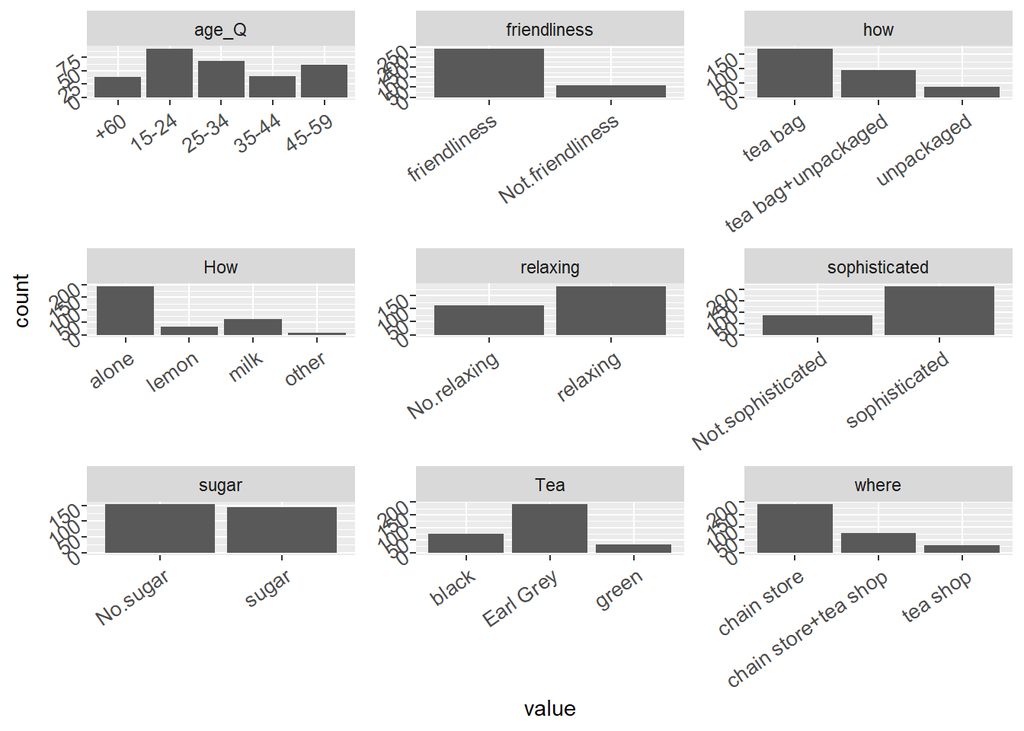

```r
#visualize the dataset
pivot_longer(tea_percep, cols = everything()) %>%
  ggplot(aes(value)) + facet_wrap("name", scales = "free") + geom_bar() + theme(axis.text = element_text(angle = 35, hjust = 1, size = 10))
```

From the plots (which are clearer if you see them with R studio) we can see that tea drinking is more common among young people than among the old. Most people connect tea drinking with friendliness a little bit less common is to connect tea drinking with sophistication. Nearly 2/3 seem to think that drinking tea is relaxing. Most people drink their tea just as it is, without adding lemon, milk or something else. However, adding sugar divides the group almost to two equal sized groups. Majority of the people surveyed buy their from chain stores and they also usually buy tea bags. And when they buy thea, it most commonly is Earl Grey.

## Multiple Correspondnce Analysis

```r
# multiple correspondence analysis
tea_mca <- MCA(tea_percep, graph = FALSE)

# summary of the model
summary(tea_mca)
```

```
##
## Call:
## MCA(X = tea_percep, graph = FALSE)
##
##
## Eigenvalues
##                        Dim.1   Dim.2   Dim.3   Dim.4   Dim.5   Dim.6   Dim.7
## Variance               0.219   0.180   0.171   0.145   0.140   0.123   0.119
## % of var.             11.596   9.548   9.076   7.695   7.397   6.490   6.295
## Cumulative % of var.  11.596  21.144  30.220  37.916  45.312  51.802  58.096
##                        Dim.8   Dim.9  Dim.10  Dim.11  Dim.12  Dim.13  Dim.14
## Variance               0.111   0.100   0.098   0.095   0.091   0.079   0.069
## % of var.              5.886   5.305   5.187   5.006   4.837   4.181   3.638
## Cumulative % of var.  63.982  69.287  74.474  79.480  84.318  88.499  92.137
##                       Dim.15  Dim.16  Dim.17
## Variance               0.064   0.048   0.036
## % of var.              3.404   2.529   1.931
## Cumulative % of var.  95.540  98.069 100.000
##
## Individuals (the 10 first)
##                       Dim.1    ctr   cos2    Dim.2    ctr   cos2    Dim.3
## 1                  | -0.179  0.049  0.014 | -0.143  0.038  0.009 |  0.662
## 2                  |  0.007  0.000  0.000 | -0.205  0.078  0.018 |  1.197
## 3                  | -0.261  0.104  0.058 | -0.226  0.094  0.043 |  0.411
## 4                  | -0.668  0.679  0.368 | -0.321  0.191  0.085 | -0.070
## 5                  | -0.261  0.104  0.058 | -0.226  0.094  0.043 |  0.411
## 6                  | -0.655  0.652  0.298 | -0.242  0.108  0.041 |  0.289
## 7                  | -0.349  0.185  0.064 | -0.149  0.041  0.012 |  0.476
## 8                  |  0.083  0.010  0.004 |  0.163  0.049  0.014 |  0.611
## 9                  |  0.129  0.025  0.007 |  0.630  0.733  0.162 |  0.166
## 10                 |  0.265  0.107  0.032 |  0.806  1.200  0.301 |  0.227
##                       ctr   cos2
## 1                   0.851  0.189 |
## 2                   2.785  0.604 |
## 3                   0.328  0.143 |
## 4                   0.010  0.004 |
## 5                   0.328  0.143 |
## 6                   0.163  0.058 |
## 7                   0.440  0.119 |
## 8                   0.725  0.200 |
```

[output cut: 23 more lines]

```
## tea bag            |  0.366  4.915  0.175  7.234 |
## tea bag+unpackaged | -0.432  3.787  0.085 -5.044 |
## unpackaged         | -0.600  2.799  0.049 -3.831 |
##
## Categorical variables (eta2)
##                      Dim.1 Dim.2 Dim.3
## Tea                | 0.207 0.168 0.240 |
## How                | 0.034 0.280 0.204 |
## how                | 0.494 0.335 0.177 |
## sugar              | 0.140 0.004 0.185 |
## where              | 0.517 0.622 0.137 |
## age_Q              | 0.406 0.150 0.419 |
## relaxing           | 0.066 0.017 0.043 |
## sophisticated      | 0.097 0.006 0.047 |
## friendliness       | 0.011 0.041 0.090 |
```

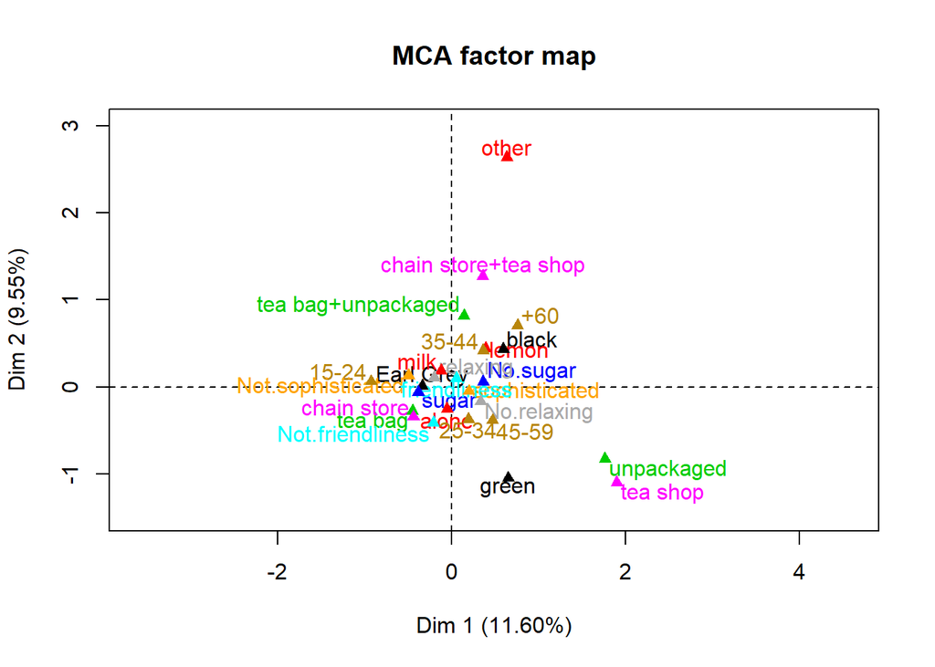

```r
# visualize MCA
plot(tea_mca, invisible=c("ind"), graph.type = "classic", habillage = "quali")
```

## Interpret the results

First of all our model does not explain much, as it only explains just over 20% of the variation. This sead, we can make some conclusions (This might not be too clear from the knitted version, I used enlarged version of the plot to see it more clearly):

1. The age group 35-44 likes to add lemon in their tea
2. This previous group uses black tea and add lemon to it
3. People 60 or over drink black tea
4. It seems that unpacked tea is usually bough from tea shops
5. Tea bags are bought from chain stores
6. People who drink Earl Grey are likely to add sugar in their tea

But these are just indicators and by looking at the numbers more carefully, we might actually find that these are not very significant relationships at all.

## Check the Screeplot

Just to visualize the percentages of inertia explained by each MCA dimensions we can as our last step use fviz_screeplot() from the factoextra package:

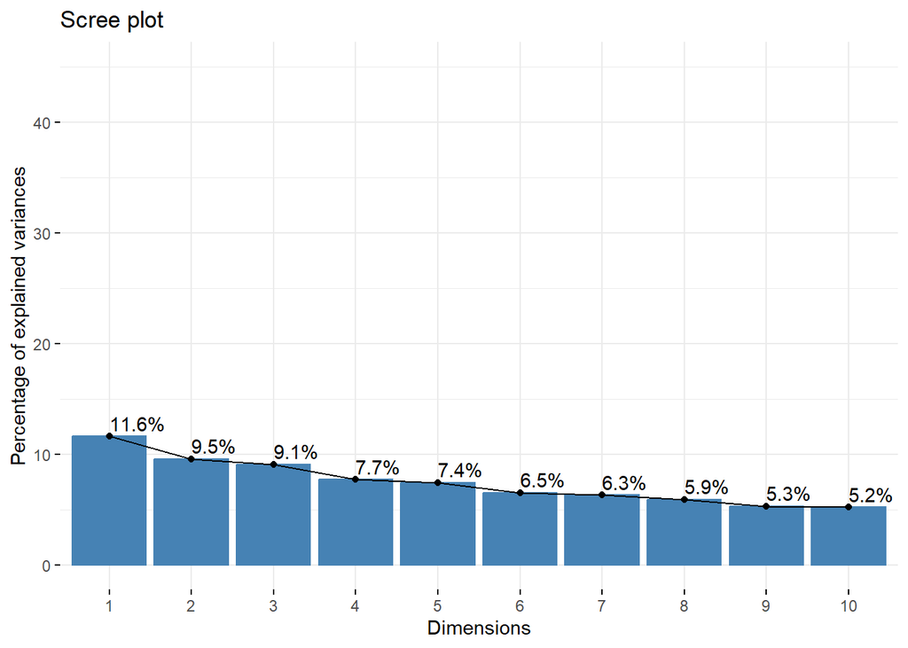

```r
fviz_screeplot(tea_mca, addlabels = TRUE, ylim = c(0, 45))
```

As you can see, it’s quite flat

Just for fun, let’s see it for the whole dataset. We put age as supplementary quantitative variable, as it is a continuour number (integer) and not a factor. Then we can place the perception questions and questions that categorize the individuals as qualitative supplementary variables.

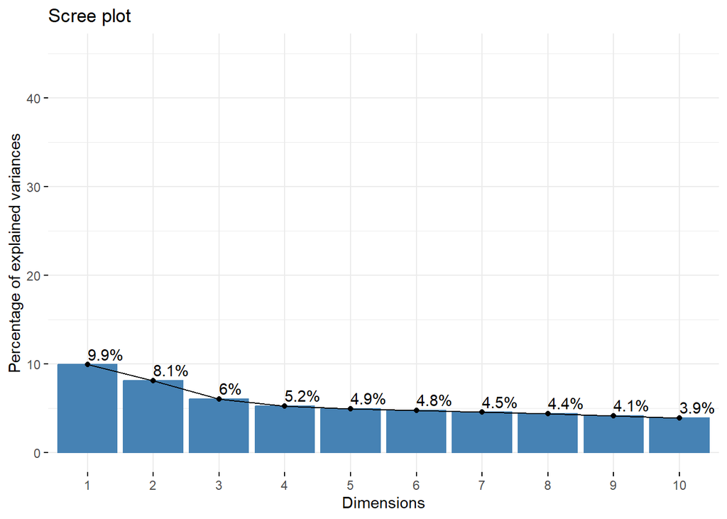

```r
res.mca <- MCA(tea, quanti.sup = 19, quali.sup = c(20:36), graph = FALSE)
fviz_screeplot(res.mca, addlabels = TRUE, ylim = c(0, 45))
```

As we can see, the variables by themselves are not explaining much. The first 10 variables explain just over 50% of the variation in the dataset.